# Investigating Medical No-Show Appointments Dataset

- Introduction
- Data Wrangling
- Exploratory Data Analysis
- Conclusions

## Introduction

> his dataset collects information from 100k medical appointments in Brazil and is focused on the question of whether or not patients show up for their appointment. A number of characteristics about the patient are included in each row
- ‘ScheduledDay’ tells us on what day the patient set up their appointment.
- ‘Neighborhood’ indicates the location of the hospital.
- ‘Scholarship’ indicates whether or not the patient is enrolled in Brasilian welfare program Bolsa Família.
- The ‘No-Show’ column: it says ‘No’ if the patient showed up to their appointment, and ‘Yes’ if they did not show up.

## Research Questions

- ### What is the overall precentage of no-show appointments?
- ### Is there a corelation between gender and no-show appointments?
- ### Does Receiving SMS have an effect on showing up?
- ### Does the Neighbourhood effect showing up to the appointment?
- ### General search on numirc features that might have an effect on showing up.
- ### Does frequently Scheduled patients tend to show up more?
- ### Does the day of the week effects no-show appointments?
- ### Does the waiting days effects no-show appointments?

```python
# imports
import pandas as pd
import numpy as np
import matplotlib.pyplot as plt
%matplotlib inline
```

## Data Wrangling

### General Properties

```python
# Load your data and print out a few lines. Perform operations to inspect data
df = pd.read_csv('noshowappointments-kagglev2-may-2016.csv')
df.head()
```

|  | PatientId | AppointmentID | Gender | ScheduledDay | AppointmentDay | Age | Neighbourhood | Scholarship | Hipertension | Diabetes | Alcoholism | Handcap | SMS_received | No-show |
| --- | --- | --- | --- | --- | --- | --- | --- | --- | --- | --- | --- | --- | --- | --- |
| 0 | 2.987250e+13 | 5642903 | F | 2016-04-29T18:38:08Z | 2016-04-29T00:00:00Z | 62 | JARDIM DA PENHA | 0 | 1 | 0 | 0 | 0 | 0 | No |
| 1 | 5.589978e+14 | 5642503 | M | 2016-04-29T16:08:27Z | 2016-04-29T00:00:00Z | 56 | JARDIM DA PENHA | 0 | 0 | 0 | 0 | 0 | 0 | No |
| 2 | 4.262962e+12 | 5642549 | F | 2016-04-29T16:19:04Z | 2016-04-29T00:00:00Z | 62 | MATA DA PRAIA | 0 | 0 | 0 | 0 | 0 | 0 | No |
| 3 | 8.679512e+11 | 5642828 | F | 2016-04-29T17:29:31Z | 2016-04-29T00:00:00Z | 8 | PONTAL DE CAMBURI | 0 | 0 | 0 | 0 | 0 | 0 | No |
| 4 | 8.841186e+12 | 5642494 | F | 2016-04-29T16:07:23Z | 2016-04-29T00:00:00Z | 56 | JARDIM DA PENHA | 0 | 1 | 1 | 0 | 0 | 0 | No |

```python
df.info()
```

```
<class 'pandas.core.frame.DataFrame'>
RangeIndex: 110527 entries, 0 to 110526
Data columns (total 14 columns):
 #   Column          Non-Null Count   Dtype
---  ------          --------------   -----
 0   PatientId       110527 non-null  float64
 1   AppointmentID   110527 non-null  int64
 2   Gender          110527 non-null  object
 3   ScheduledDay    110527 non-null  object
 4   AppointmentDay  110527 non-null  object
 5   Age             110527 non-null  int64
 6   Neighbourhood   110527 non-null  object
 7   Scholarship     110527 non-null  int64
 8   Hipertension    110527 non-null  int64
 9   Diabetes        110527 non-null  int64
 10  Alcoholism      110527 non-null  int64
 11  Handcap         110527 non-null  int64
 12  SMS_received    110527 non-null  int64
 13  No-show         110527 non-null  object
dtypes: float64(1), int64(8), object(5)
memory usage: 11.8+ MB
```

##### Patient ID should be integer not a float number, ScheduledDay and AppointmentDay should be datetime not strings

```python
df.shape
```

```
(110527, 14)
```

```python
df.describe()
```

|  | PatientId | AppointmentID | Age | Scholarship | Hipertension | Diabetes | Alcoholism | Handcap | SMS_received |
| --- | --- | --- | --- | --- | --- | --- | --- | --- | --- |
| count | 1.105270e+05 | 1.105270e+05 | 110527.000000 | 110527.000000 | 110527.000000 | 110527.000000 | 110527.000000 | 110527.000000 | 110527.000000 |
| mean | 1.474963e+14 | 5.675305e+06 | 37.088874 | 0.098266 | 0.197246 | 0.071865 | 0.030400 | 0.022248 | 0.321026 |
| std | 2.560949e+14 | 7.129575e+04 | 23.110205 | 0.297675 | 0.397921 | 0.258265 | 0.171686 | 0.161543 | 0.466873 |
| min | 3.921784e+04 | 5.030230e+06 | -1.000000 | 0.000000 | 0.000000 | 0.000000 | 0.000000 | 0.000000 | 0.000000 |
| 25% | 4.172614e+12 | 5.640286e+06 | 18.000000 | 0.000000 | 0.000000 | 0.000000 | 0.000000 | 0.000000 | 0.000000 |
| 50% | 3.173184e+13 | 5.680573e+06 | 37.000000 | 0.000000 | 0.000000 | 0.000000 | 0.000000 | 0.000000 | 0.000000 |
| 75% | 9.439172e+13 | 5.725524e+06 | 55.000000 | 0.000000 | 0.000000 | 0.000000 | 0.000000 | 0.000000 | 1.000000 |
| max | 9.999816e+14 | 5.790484e+06 | 115.000000 | 1.000000 | 1.000000 | 1.000000 | 1.000000 | 4.000000 | 1.000000 |

##### Seems like there are no missing Data, But there are useless column we don't need which is Appointment ID, it can be removed and minimum age is -1 which can't be right

```python
df.Handcap.value_counts()
```

```
0    108286
1      2042
2       183
3        13
4         3
Name: Handcap, dtype: int64
```

Seems like handcap got specific values for different types of handcap, it doesn't make much difference for us so we'll change all values above 1 to 1

```python
sum(df.drop('AppointmentID',axis=1).duplicated())
# We excluded the Appointment ID to be able to see actual duplicates.
```

```
618
```

```python
df[df.Age <= 0].Age.value_counts()
```

```
 0    3539
-1       1
Name: Age, dtype: int64
```

```python
df[df.Age <= 0].PatientId.nunique()
```

```
2083
```

```python
df[df.Age <= 0].PatientId.unique()
```

```
array([7.18442847e+13, 2.36623345e+14, 1.88517385e+14, ...,
       3.27937316e+14, 8.53573435e+12, 3.73174629e+12])
```

There is a lot of data with age of 0 and under for 2083 patients, with total of 3540 record  
I will check if those patient IDs always have those ages because there's a chance that maybe their correct age is recorded somewhere else in the data.

```python
df.loc[df['PatientId'].isin(df[df.Age <= 0].PatientId.unique())].Age.value_counts()
```

```
 0    3539
 1      82
-1       1
Name: Age, dtype: int64
```

```python
df.PatientId.nunique()
```

```
62299
```

### Data Cleaning

> **Note**: The Data is mostly clean, it will just require few modifications like splitting the data, converting data types, dropping duplicated, adding extra columns and fixing/removing any bad data.
1. **Dropping rows with age = 0 and under.**
2. **Dropping remove the appointment ID column.**
3. **Dropping duplicated values.**
4. **Changing all handcap values that are more than 1 to 1.**
5. **Converting ScheduledDay & AppointmentDay to Datetime.**
6. **Converting PatientId to integer.**
7. **Adding DOW (Day Of Week) column based on Appointment Day.**
8. **Adding WaitingDays column based on AppointmentDay - ScheduledDay.**
9. **Split Data to Show and NoShow.**

```python
# 1. Dropping rows with age = 0 and under.
df.drop(df[df.Age <= 0].index,axis=0,inplace=True)

# 2. Dropping remove the appointment ID column.
df.drop('AppointmentID',axis=1, inplace=True)

df.shape
```

```
(106987, 13)
```

```python
df.duplicated().sum()
```

```
609
```

```python
# 3. Dropping Duplicated values.
df.drop_duplicates(inplace=True)
df.shape
```

```
(106378, 13)
```

```python
# 4. Changing all handcap values that are more than 1 to 1.
df[df['Handcap']>1] = 1
df[df['Handcap']>1]
```

|  | PatientId | Gender | ScheduledDay | AppointmentDay | Age | Neighbourhood | Scholarship | Hipertension | Diabetes | Alcoholism | Handcap | SMS_received | No-show |
| --- | --- | --- | --- | --- | --- | --- | --- | --- | --- | --- | --- | --- | --- |

```python
df.Handcap.value_counts()
```

```
0    104160
1      2218
Name: Handcap, dtype: int64
```

```python
#Checking values
df.Neighbourhood.unique()
```

```
array(['JARDIM DA PENHA', 'MATA DA PRAIA', 'PONTAL DE CAMBURI',
       'REPÚBLICA', 'GOIABEIRAS', 'ANDORINHAS', 'CONQUISTA',
       'NOVA PALESTINA', 'DA PENHA', 'TABUAZEIRO', 'BENTO FERREIRA',
       'SÃO PEDRO', 'SANTA MARTHA', 'SÃO CRISTÓVÃO', 'MARUÍPE',
       'GRANDE VITÓRIA', 'SANTO ANDRÉ', 'SOLON BORGES', 'BONFIM',
       'JARDIM CAMBURI', 'MARIA ORTIZ', 'JABOUR', 'ANTÔNIO HONÓRIO',
       'RESISTÊNCIA', 'ILHA DE SANTA MARIA', 'JUCUTUQUARA',
       'MÁRIO CYPRESTE', 'SANTO ANTÔNIO', 'BELA VISTA', 'PRAIA DO SUÁ',
       'SANTA HELENA', 'ITARARÉ', 'INHANGUETÁ', 'UNIVERSITÁRIO',
       'SÃO JOSÉ', 'REDENÇÃO', 'SANTA CLARA', 'CENTRO', 'PARQUE MOSCOSO',
       'DO MOSCOSO', 'SANTOS DUMONT', 'CARATOÍRA', 'ARIOVALDO FAVALESSA',
       'ILHA DO FRADE', 'GURIGICA', 'JOANA D´ARC', 'CONSOLAÇÃO',
       'SÃO BENEDITO', 'PRAIA DO CANTO', 'BOA VISTA', 'SANTA LÚCIA',
       'BARRO VERMELHO', 'ESTRELINHA', 'FORTE SÃO JOÃO', 'FONTE GRANDE',
       'MORADA DE CAMBURI', 'ENSEADA DO SUÁ', 'SANTOS REIS', 'PIEDADE',
       'JESUS DE NAZARETH', 'SANTA LUÍZA', 'SANTA TEREZA', 'CRUZAMENTO',
       'ILHA DO PRÍNCIPE', 'ROMÃO', 'ILHA DAS CAIEIRAS', 'COMDUSA',
       'SANTA CECÍLIA', 'VILA RUBIM', 'DE LOURDES', 1, 'MONTE BELO',
       'DO QUADRO', 'DO CABRAL', 'HORTO', 'SEGURANÇA DO LAR',
       'ILHA DO BOI', 'FRADINHOS', 'NAZARETH', 'AEROPORTO',
       'ILHAS OCEÂNICAS DE TRINDADE', 'PARQUE INDUSTRIAL'], dtype=object)
```

```python
df[df.Neighbourhood==1]
```

|  | PatientId | Gender | ScheduledDay | AppointmentDay | Age | Neighbourhood | Scholarship | Hipertension | Diabetes | Alcoholism | Handcap | SMS_received | No-show |
| --- | --- | --- | --- | --- | --- | --- | --- | --- | --- | --- | --- | --- | --- |
| 946 | 1.0 | 1 | 1 | 1 | 1 | 1 | 1 | 1 | 1 | 1 | 1 | 1 | 1 |
| 1665 | 1.0 | 1 | 1 | 1 | 1 | 1 | 1 | 1 | 1 | 1 | 1 | 1 | 1 |
| 1666 | 1.0 | 1 | 1 | 1 | 1 | 1 | 1 | 1 | 1 | 1 | 1 | 1 | 1 |
| 2071 | 1.0 | 1 | 1 | 1 | 1 | 1 | 1 | 1 | 1 | 1 | 1 | 1 | 1 |
| 2091 | 1.0 | 1 | 1 | 1 | 1 | 1 | 1 | 1 | 1 | 1 | 1 | 1 | 1 |
| ... | ... | ... | ... | ... | ... | ... | ... | ... | ... | ... | ... | ... | ... |
| 108376 | 1.0 | 1 | 1 | 1 | 1 | 1 | 1 | 1 | 1 | 1 | 1 | 1 | 1 |
| 109484 | 1.0 | 1 | 1 | 1 | 1 | 1 | 1 | 1 | 1 | 1 | 1 | 1 | 1 |
| 109733 | 1.0 | 1 | 1 | 1 | 1 | 1 | 1 | 1 | 1 | 1 | 1 | 1 | 1 |
| 109975 | 1.0 | 1 | 1 | 1 | 1 | 1 | 1 | 1 | 1 | 1 | 1 | 1 | 1 |
| 110107 | 1.0 | 1 | 1 | 1 | 1 | 1 | 1 | 1 | 1 | 1 | 1 | 1 | 1 |

196 rows × 13 columns

```python
df.drop(df[df.Neighbourhood==1].index, axis=0, inplace=True)
```

```python
df[df.Neighbourhood==1]
```

|  | PatientId | Gender | ScheduledDay | AppointmentDay | Age | Neighbourhood | Scholarship | Hipertension | Diabetes | Alcoholism | Handcap | SMS_received | No-show |
| --- | --- | --- | --- | --- | --- | --- | --- | --- | --- | --- | --- | --- | --- |

```python
df.shape
```

```
(106182, 13)
```

```python
# 5. Converting ScheduledDay & AppointmentDay to Datetime.
df['AppointmentDay'] = pd.to_datetime(df['AppointmentDay'],format='%Y-%m-%dT%H:%M:%SZ')
df['ScheduledDay'] = pd.to_datetime(df['ScheduledDay'], format='%Y-%m-%dT%H:%M:%SZ').dt.normalize()
df.info()
```

```
<class 'pandas.core.frame.DataFrame'>
Int64Index: 106182 entries, 0 to 110526
Data columns (total 13 columns):
 #   Column          Non-Null Count   Dtype
---  ------          --------------   -----
 0   PatientId       106182 non-null  float64
 1   Gender          106182 non-null  object
 2   ScheduledDay    106182 non-null  datetime64[ns]
 3   AppointmentDay  106182 non-null  datetime64[ns]
 4   Age             106182 non-null  int64
 5   Neighbourhood   106182 non-null  object
 6   Scholarship     106182 non-null  int64
 7   Hipertension    106182 non-null  int64
 8   Diabetes        106182 non-null  int64
 9   Alcoholism      106182 non-null  int64
 10  Handcap         106182 non-null  int64
 11  SMS_received    106182 non-null  int64
 12  No-show         106182 non-null  object
dtypes: datetime64[ns](2), float64(1), int64(7), object(3)
memory usage: 11.3+ MB
```

```python
df.head(1)
```

|  | PatientId | Gender | ScheduledDay | AppointmentDay | Age | Neighbourhood | Scholarship | Hipertension | Diabetes | Alcoholism | Handcap | SMS_received | No-show |
| --- | --- | --- | --- | --- | --- | --- | --- | --- | --- | --- | --- | --- | --- |
| 0 | 2.987250e+13 | F | 2016-04-29 | 2016-04-29 | 62 | JARDIM DA PENHA | 0 | 1 | 0 | 0 | 0 | 0 | No |

```python
# 6. Converting PatientId to integer.
df['PatientId']=df['PatientId'].astype('int64')
df.head(1)
```

|  | PatientId | Gender | ScheduledDay | AppointmentDay | Age | Neighbourhood | Scholarship | Hipertension | Diabetes | Alcoholism | Handcap | SMS_received | No-show |
| --- | --- | --- | --- | --- | --- | --- | --- | --- | --- | --- | --- | --- | --- |
| 0 | 29872499824296 | F | 2016-04-29 | 2016-04-29 | 62 | JARDIM DA PENHA | 0 | 1 | 0 | 0 | 0 | 0 | No |

```python
df.info()
```

```
<class 'pandas.core.frame.DataFrame'>
Int64Index: 106182 entries, 0 to 110526
Data columns (total 13 columns):
 #   Column          Non-Null Count   Dtype
---  ------          --------------   -----
 0   PatientId       106182 non-null  int64
 1   Gender          106182 non-null  object
 2   ScheduledDay    106182 non-null  datetime64[ns]
 3   AppointmentDay  106182 non-null  datetime64[ns]
 4   Age             106182 non-null  int64
 5   Neighbourhood   106182 non-null  object
 6   Scholarship     106182 non-null  int64
 7   Hipertension    106182 non-null  int64
 8   Diabetes        106182 non-null  int64
 9   Alcoholism      106182 non-null  int64
 10  Handcap         106182 non-null  int64
 11  SMS_received    106182 non-null  int64
 12  No-show         106182 non-null  object
dtypes: datetime64[ns](2), int64(8), object(3)
memory usage: 11.3+ MB
```

```python
# 7. Adding DOW (Day Of Week) column based on Appointment Day.
df['DOW'] = df['AppointmentDay'].dt.day_name()
df.head(1)
```

|  | PatientId | Gender | ScheduledDay | AppointmentDay | Age | Neighbourhood | Scholarship | Hipertension | Diabetes | Alcoholism | Handcap | SMS_received | No-show | DOW |
| --- | --- | --- | --- | --- | --- | --- | --- | --- | --- | --- | --- | --- | --- | --- |
| 0 | 29872499824296 | F | 2016-04-29 | 2016-04-29 | 62 | JARDIM DA PENHA | 0 | 1 | 0 | 0 | 0 | 0 | No | Friday |

```python
# Checking if there are any appointment days before scheduled day and removing them
df[df['AppointmentDay']<df['ScheduledDay']]
```

|  | PatientId | Gender | ScheduledDay | AppointmentDay | Age | Neighbourhood | Scholarship | Hipertension | Diabetes | Alcoholism | Handcap | SMS_received | No-show | DOW |
| --- | --- | --- | --- | --- | --- | --- | --- | --- | --- | --- | --- | --- | --- | --- |
| 27033 | 7839272661752 | M | 2016-05-10 | 2016-05-09 | 38 | RESISTÊNCIA | 0 | 0 | 0 | 0 | 1 | 0 | Yes | Monday |
| 55226 | 7896293967868 | F | 2016-05-18 | 2016-05-17 | 19 | SANTO ANTÔNIO | 0 | 0 | 0 | 0 | 1 | 0 | Yes | Tuesday |
| 64175 | 24252258389979 | F | 2016-05-05 | 2016-05-04 | 22 | CONSOLAÇÃO | 0 | 0 | 0 | 0 | 0 | 0 | Yes | Wednesday |
| 71533 | 998231581612122 | F | 2016-05-11 | 2016-05-05 | 81 | SANTO ANTÔNIO | 0 | 0 | 0 | 0 | 0 | 0 | Yes | Thursday |
| 72362 | 3787481966821 | M | 2016-05-04 | 2016-05-03 | 7 | TABUAZEIRO | 0 | 0 | 0 | 0 | 0 | 0 | Yes | Tuesday |

```python
df.drop(df[df['AppointmentDay']<df['ScheduledDay']].index, axis=0, inplace=True)
```

```python
df[df['AppointmentDay']<df['ScheduledDay']]
```

|  | PatientId | Gender | ScheduledDay | AppointmentDay | Age | Neighbourhood | Scholarship | Hipertension | Diabetes | Alcoholism | Handcap | SMS_received | No-show | DOW |
| --- | --- | --- | --- | --- | --- | --- | --- | --- | --- | --- | --- | --- | --- | --- |

```python
# 8. Adding WaitingDays column based on AppointmentDay - ScheduledDay.
df['WaitingDays'] = (df['AppointmentDay']-df['ScheduledDay'])
df.head(1)
```

|  | PatientId | Gender | ScheduledDay | AppointmentDay | Age | Neighbourhood | Scholarship | Hipertension | Diabetes | Alcoholism | Handcap | SMS_received | No-show | DOW | WaitingDays |
| --- | --- | --- | --- | --- | --- | --- | --- | --- | --- | --- | --- | --- | --- | --- | --- |
| 0 | 29872499824296 | F | 2016-04-29 | 2016-04-29 | 62 | JARDIM DA PENHA | 0 | 1 | 0 | 0 | 0 | 0 | No | Friday | 0 days |

```python
df.info()
```

```
<class 'pandas.core.frame.DataFrame'>
Int64Index: 106177 entries, 0 to 110526
Data columns (total 15 columns):
 #   Column          Non-Null Count   Dtype
---  ------          --------------   -----
 0   PatientId       106177 non-null  int64
 1   Gender          106177 non-null  object
 2   ScheduledDay    106177 non-null  datetime64[ns]
 3   AppointmentDay  106177 non-null  datetime64[ns]
 4   Age             106177 non-null  int64
 5   Neighbourhood   106177 non-null  object
 6   Scholarship     106177 non-null  int64
 7   Hipertension    106177 non-null  int64
 8   Diabetes        106177 non-null  int64
 9   Alcoholism      106177 non-null  int64
 10  Handcap         106177 non-null  int64
 11  SMS_received    106177 non-null  int64
 12  No-show         106177 non-null  object
 13  DOW             106177 non-null  object
 14  WaitingDays     106177 non-null  timedelta64[ns]
dtypes: datetime64[ns](2), int64(8), object(4), timedelta64[ns](1)
memory usage: 13.0+ MB
```

```python
# Rearrenging columns for cleanlness
cols = list(df.columns.values)
cols = ['PatientId',
 'Gender',
 'ScheduledDay',
 'AppointmentDay',
 'WaitingDays',
 'DOW',
 'Age',
 'Neighbourhood',
 'Scholarship',
 'Hipertension',
 'Diabetes',
 'Alcoholism',
 'Handcap',
 'SMS_received',
 'No-show']
df = df[cols]
df.head(1)
```

|  | PatientId | Gender | ScheduledDay | AppointmentDay | WaitingDays | DOW | Age | Neighbourhood | Scholarship | Hipertension | Diabetes | Alcoholism | Handcap | SMS_received | No-show |
| --- | --- | --- | --- | --- | --- | --- | --- | --- | --- | --- | --- | --- | --- | --- | --- |
| 0 | 29872499824296 | F | 2016-04-29 | 2016-04-29 | 0 days | Friday | 62 | JARDIM DA PENHA | 0 | 1 | 0 | 0 | 0 | 0 | No |

```python
df.describe()
```

|  | PatientId | WaitingDays | Age | Scholarship | Hipertension | Diabetes | Alcoholism | Handcap | SMS_received |
| --- | --- | --- | --- | --- | --- | --- | --- | --- | --- |
| count | 1.061770e+05 | 106177 | 106177.000000 | 106177.000000 | 106177.000000 | 106177.000000 | 106177.000000 | 106177.000000 | 106177.000000 |
| mean | 1.472580e+14 | 10 days 03:24:27.063488326 | 38.301374 | 0.101077 | 0.203368 | 0.073933 | 0.031438 | 0.019025 | 0.325287 |
| std | 2.558032e+14 | 15 days 06:16:52.511914994 | 22.463079 | 0.301431 | 0.402506 | 0.261663 | 0.174499 | 0.136613 | 0.468484 |
| min | 3.921700e+04 | 0 days 00:00:00 | 1.000000 | 0.000000 | 0.000000 | 0.000000 | 0.000000 | 0.000000 | 0.000000 |
| 25% | 4.175888e+12 | 0 days 00:00:00 | 19.000000 | 0.000000 | 0.000000 | 0.000000 | 0.000000 | 0.000000 | 0.000000 |
| 50% | 3.173184e+13 | 4 days 00:00:00 | 38.000000 | 0.000000 | 0.000000 | 0.000000 | 0.000000 | 0.000000 | 0.000000 |
| 75% | 9.433654e+13 | 14 days 00:00:00 | 56.000000 | 0.000000 | 0.000000 | 0.000000 | 0.000000 | 0.000000 | 1.000000 |
| max | 9.999816e+14 | 179 days 00:00:00 | 115.000000 | 1.000000 | 1.000000 | 1.000000 | 1.000000 | 1.000000 | 1.000000 |

```python
# 9. Split Data to Show and NoShow.
df.rename(columns={"No-show": "no_show"},inplace=True)
#testing with masks
#showed = df.no_show == 'No'
#noshow = df.no_show == 'Yes'
showed = df[df['no_show']=='No']
noshow = df[df['no_show']=='Yes']
```

```python
showed.describe()
```

|  | PatientId | WaitingDays | Age | Scholarship | Hipertension | Diabetes | Alcoholism | Handcap | SMS_received |
| --- | --- | --- | --- | --- | --- | --- | --- | --- | --- |
| count | 8.475400e+04 | 84754 | 84754.000000 | 84754.000000 | 84754.000000 | 84754.000000 | 84754.000000 | 84754.000000 | 84754.000000 |
| mean | 1.474773e+14 | 8 days 17:17:28.899167001 | 39.070357 | 0.096550 | 0.211046 | 0.075937 | 0.031527 | 0.019633 | 0.294724 |
| std | 2.561294e+14 | 14 days 13:26:17.528888004 | 22.650647 | 0.295346 | 0.408053 | 0.264900 | 0.174737 | 0.138737 | 0.455921 |
| min | 3.921700e+04 | 0 days 00:00:00 | 1.000000 | 0.000000 | 0.000000 | 0.000000 | 0.000000 | 0.000000 | 0.000000 |
| 25% | 4.171385e+12 | 0 days 00:00:00 | 20.000000 | 0.000000 | 0.000000 | 0.000000 | 0.000000 | 0.000000 | 0.000000 |
| 50% | 3.175985e+13 | 2 days 00:00:00 | 39.000000 | 0.000000 | 0.000000 | 0.000000 | 0.000000 | 0.000000 | 0.000000 |
| 75% | 9.425925e+13 | 12 days 00:00:00 | 57.000000 | 0.000000 | 0.000000 | 0.000000 | 0.000000 | 0.000000 | 1.000000 |
| max | 9.999816e+14 | 179 days 00:00:00 | 115.000000 | 1.000000 | 1.000000 | 1.000000 | 1.000000 | 1.000000 | 1.000000 |

```python
noshow.describe()
```

|  | PatientId | WaitingDays | Age | Scholarship | Hipertension | Diabetes | Alcoholism | Handcap | SMS_received |
| --- | --- | --- | --- | --- | --- | --- | --- | --- | --- |
| count | 2.142300e+04 | 21423 | 21423.000000 | 21423.000000 | 21423.000000 | 21423.000000 | 21423.000000 | 21423.000000 | 21423.000000 |
| mean | 1.463907e+14 | 15 days 18:22:42.162162162 | 35.259114 | 0.118984 | 0.172992 | 0.066004 | 0.031088 | 0.016618 | 0.446203 |
| std | 2.545125e+14 | 16 days 14:47:47.965214595 | 21.436878 | 0.323778 | 0.378249 | 0.248295 | 0.173560 | 0.127837 | 0.497109 |
| min | 5.628261e+06 | 0 days 00:00:00 | 1.000000 | 0.000000 | 0.000000 | 0.000000 | 0.000000 | 0.000000 | 0.000000 |
| 25% | 4.188544e+12 | 4 days 00:00:00 | 18.000000 | 0.000000 | 0.000000 | 0.000000 | 0.000000 | 0.000000 | 0.000000 |
| 50% | 3.156794e+13 | 10 days 00:00:00 | 33.000000 | 0.000000 | 0.000000 | 0.000000 | 0.000000 | 0.000000 | 0.000000 |
| 75% | 9.453734e+13 | 23 days 00:00:00 | 52.000000 | 0.000000 | 0.000000 | 0.000000 | 0.000000 | 0.000000 | 1.000000 |
| max | 9.996585e+14 | 179 days 00:00:00 | 115.000000 | 1.000000 | 1.000000 | 1.000000 | 1.000000 | 1.000000 | 1.000000 |

## Exploratory Data Analysis

### What is the overall precentage of no-show appointments?

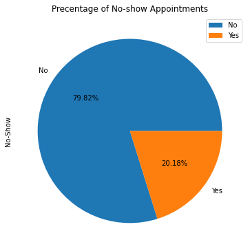

```python
# Plotting no show percentage.
df['no_show'].value_counts().plot(kind='pie',title='Precentage of No-show Appointments',label='No-Show',figsize=(6,8),autopct='%.2f%%')
plt.legend();
```

#### About 20% did not show up to their appointments!

note that "yes" means they did **Not** show up

### Is there a corelation between gender and no-show appointments?

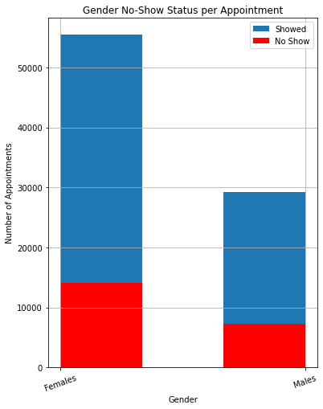

```python
showed['Gender'].hist(label='Showed',alpha=1,bins=3,figsize=(6,8))
noshow['Gender'].hist(label='No Show',alpha=1,color="red",bins=3);
plt.xticks([0, 1], ['Females', 'Males'], rotation=20)
plt.title('Gender No-Show Status per Appointment')
plt.xlabel('Gender')
plt.ylabel('Number of Appointments')
plt.legend();
```

#### Seems like the gender doesn't effect no-show appointments but there are more females going to medical appoints than males

### Does Receiving SMS have an effect on showing up?

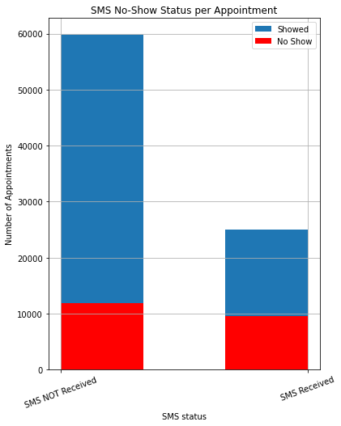

```python
# Checking if Receiving SMS have an effect on patient showing.
showed['SMS_received'].hist(label='Showed',alpha=1,bins=3,figsize=(6,8))
noshow['SMS_received'].hist(label='No Show',alpha=1,color="red",bins=3);
plt.xticks([0, 1], ['SMS NOT Received', 'SMS Received'], rotation=20)
plt.title('SMS No-Show Status per Appointment')
plt.xlabel('SMS status')
plt.ylabel('Number of Appointments')
plt.legend();
```

```python
print(round(noshow.SMS_received.mean() * 100,2) ,'% of people who received SMS did NOT show up,' )
```

[output not shown]

#### Weirdly enough it seems like receiving SMS have negative impact on patient showing up, requires further investigation.

#### Maybe the wording of the SMS is misleading?

### Does the Neighbourhood effect showing up to the appointment?

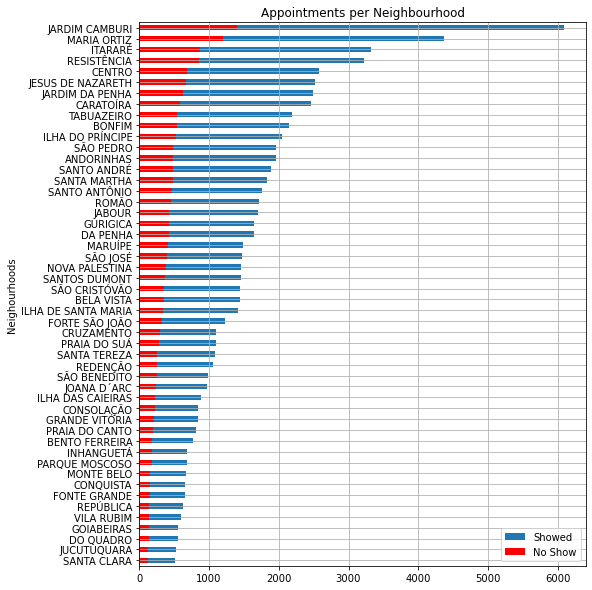

```python
showed['Neighbourhood'].value_counts(ascending=True).tail(50).plot(kind='barh',label='Showed',alpha=1,figsize=(8,10))
noshow['Neighbourhood'].value_counts(ascending=True).tail(50).plot(kind='barh',title='Appointments per Neighbourhood',xlabel='Neighourhoods',ylabel='Number of Appointments',label='No Show',alpha=1,color="red");
#plt.xticks(rotation=80)
plt.grid();
plt.legend();
```

The Neighbourhood does have a little effect on showing up to an appointment since there's a high precentage of people who go to their appointments and live in the same area.

### General search on numirc features that might have an effect on showing up:

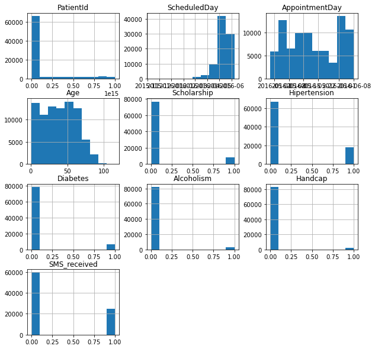

```python
showed.hist(figsize=(10,10));
```

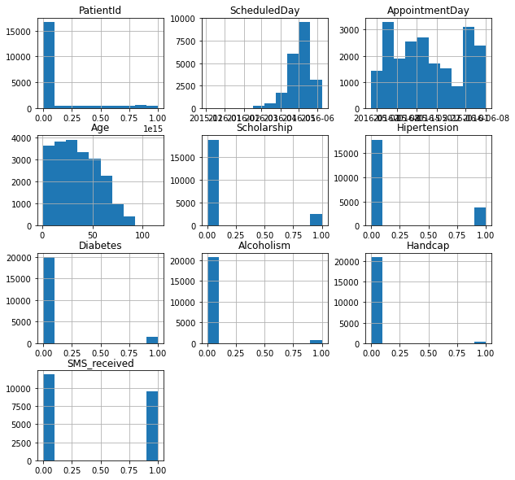

```python
noshow.hist(figsize=(10,10));
```

#### Since histrograms of both tables look very similar, it's safe to assume that Scholarship, Hipertension, Diabetes, Alcoholism, And Handicap does **not** have an effect on No-show Appointments

#### except for Age, More middle aged people show up than older and little younger ages.

### Does frequently Scheduled patients tend to show up more?

```python
# let's find the top 40 patients who show up
top_30=showed['PatientId'].value_counts().head(30).to_frame('show')
top_30.head()
```

|  | show |
| --- | --- |
| 822145925426128 | 87 |
| 99637671331 | 80 |
| 26886125921145 | 70 |
| 33534783483176 | 65 |
| 258424392677 | 62 |

```python
# Now let's check how many times those patients missed their appointments
noshow.query('PatientId in @top_30.index')['PatientId'].value_counts().to_frame('noshow').head()
```

|  | noshow |
| --- | --- |
| 1484143378533 | 7 |
| 9496196639835 | 6 |
| 14479974122994 | 5 |
| 416755661551767 | 5 |
| 99637671331 | 4 |

```python
# join the two results
top_30['noshow'] = noshow.query('PatientId in @top_30.index')['PatientId'].value_counts().to_frame('noshow')
top_30.head()
```

|  | show | noshow |
| --- | --- | --- |
| 822145925426128 | 87 | 1.0 |
| 99637671331 | 80 | 4.0 |
| 26886125921145 | 70 | NaN |
| 33534783483176 | 65 | NaN |
| 258424392677 | 62 | NaN |

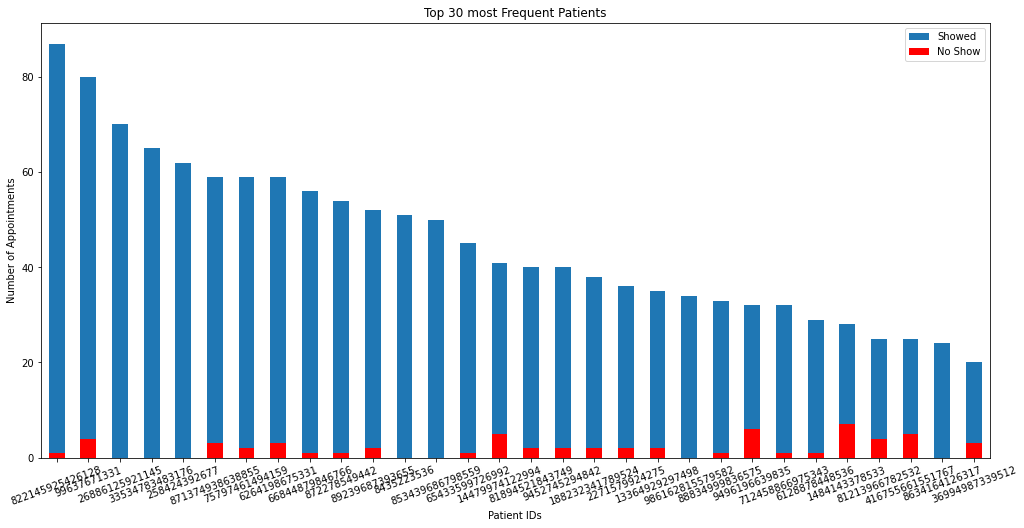

```python
# plotting the results
top_30['show'].plot(kind='bar',label='Showed',alpha=1,figsize=(17,8))
top_30['noshow'].plot(kind='bar',title='Top 30 most Frequent Patients',xlabel='Patient IDs',ylabel='Number of Appointments',label='No Show',alpha=1,color="red",figsize=(17,8));
plt.xticks(rotation=20)
plt.legend();
```

#### It's safe to assume that frequent patients will show up

### Does the day of the week effects no-show appointments?

```python
# Getting number of people who showed up on each day
showed['DOW'].value_counts(sort=False)
```

```
Friday       14388
Tuesday      19689
Monday       17276
Wednesday    20030
Thursday     13341
Saturday        30
Name: DOW, dtype: int64
```

```python
# Getting number of people who did NOT showed up on each day
noshow['DOW'].value_counts(sort=False)
```

```
Friday       3891
Tuesday      4958
Monday       4450
Thursday     3214
Wednesday    4901
Saturday        9
Name: DOW, dtype: int64
```

[figure not shown]

```python
# plotting the results
noshow['DOW'].value_counts(sort=False).plot(kind='bar',label='Showed',alpha=0.5,figsize=(9,10))
showed['DOW'].value_counts(sort=False).plot(title='Appointments per Day', xlabel='Day of the week', ylabel='Number of Appointments',kind='bar',label='No Show',alpha=0.5,color="red",figsize=(9,8));
plt.xticks(rotation=20)
plt.legend();
```

#### Seems like the day of week doesn't effect no show ups.

### Does the waiting days effects no-show appointments?

```python
# Getting waiting days for show ups
waitingdays = showed['WaitingDays'].value_counts().to_frame('shows')
waitingdays.head()
```

|  | shows |
| --- | --- |
| 0 days | 35283 |
| 2 days | 5024 |
| 4 days | 3981 |
| 1 days | 3910 |
| 7 days | 3480 |

```python
# Getting waiting days for no-show
noshow['WaitingDays'].value_counts()
```

```
0 days      1729
2 days      1572
7 days      1261
4 days      1200
1 days      1058
            ...
96 days        1
111 days       1
151 days       1
169 days       1
146 days       1
Name: WaitingDays, Length: 110, dtype: int64
```

```python
# Joining two results
waitingdays['noshow'] = noshow.query('WaitingDays in @waitingdays.index')['WaitingDays'].value_counts().to_frame('noshow')
waitingdays.head()
```

|  | shows | noshow |
| --- | --- | --- |
| 0 days | 35283 | 1729.0 |
| 2 days | 5024 | 1572.0 |
| 4 days | 3981 | 1200.0 |
| 1 days | 3910 | 1058.0 |
| 7 days | 3480 | 1261.0 |

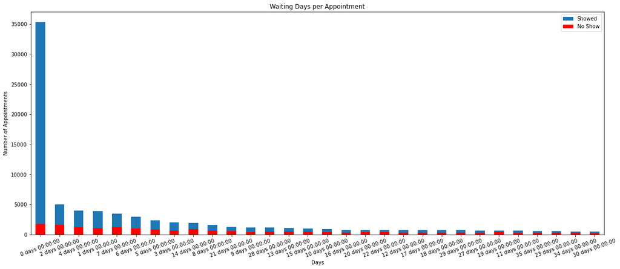

```python
# plotting results
waitingdays['shows'].head(30).plot(kind='bar',label='Showed',alpha=1,figsize=(20,8))
waitingdays['noshow'].head(30).plot(kind='bar',title='Waiting Days per Appointment', xlabel='Days',ylabel='Number of Appointments',label='No Show',alpha=1,color="red",figsize=(20,8));
plt.xticks(rotation=20)
plt.legend();
```